# HW6

Peter Jenkins

4/20/2021

#1. Load data and place into an unmarkedFramePCount object

```r
y <- read.csv('count.csv')
head(y)
```

```
##   j1 j2 j3
## 1  0  0  0
## 2  1  1  1
## 3  8 13 12
## 4  2  1  1
## 5  3  8  3
## 6  0  0  0
```

```r
# converting count data into a matrix
# matrix format required by unmarkedFramePCount
sosp_mat <- as.matrix(y)
nmix_data <- unmarkedFramePCount(y = sosp_mat)
obs_covs <- read.csv("obs_covs.csv")
head(obs_covs)
```

```
##          j1           j2         j3
## 1 0.9401255 -0.555760967 -0.3582067
## 2 2.4448899 -0.457783896  0.4253590
## 3 1.1633403  0.006345006 -0.2650346
## 4 0.7138189  0.857225770  1.5519564
## 5 2.0457416  0.077946090  1.9626749
## 6 0.7596043 -0.356677808 -0.1295560
```

```r
det_covs <- list(
  rep = obs_covs)


site_covs <- read.csv('site_covs.csv')
head(site_covs)
```

```
##            x1 x2
## 1 -1.06733947  b
## 2 -0.98588873  a
## 3 -0.09409764  d
## 4  1.32241491  a
## 5  0.45689994  d
## 6 -0.89026419  b
```

```r
site_covs$x2 <- as.factor(site_covs$x2)

nmix_data <- unmarkedFramePCount(y = sosp_mat, # counts
                                 siteCovs = site_covs,# site cov
                                 obsCovs = det_covs  # detection covariates
                                 )
```

#2. Fit an N-mixture model that assumes conditional detection probability is a function of the detection #covariate provided, and expected abundance is a additive function of variables x1 and x2.

```r
fit <- pcount(formula = ~ rep ~ x1 + x2 ,
              data = nmix_data, K = 100)
fit
```

```
##
## Call:
## pcount(formula = ~rep ~ x1 + x2, data = nmix_data, K = 100)
##
## Abundance:
##             Estimate     SE     z  P(>|z|)
## (Intercept)    0.915 0.1106  8.27 1.30e-16
## x1             0.370 0.0401  9.21 3.14e-20
## x2b           -0.161 0.1382 -1.16 2.45e-01
## x2c           -0.189 0.1522 -1.24 2.14e-01
## x2d            1.335 0.1195 11.17 5.63e-29
##
## Detection:
##             Estimate     SE     z  P(>|z|)
## (Intercept)    1.259 0.0925  13.6 4.01e-42
## rep           -0.841 0.0639 -13.2 1.57e-39
##
## AIC: 1736.028
```

#3. Interpret the effect of x1 on the expected count at each site. Verity your interpretation in R.

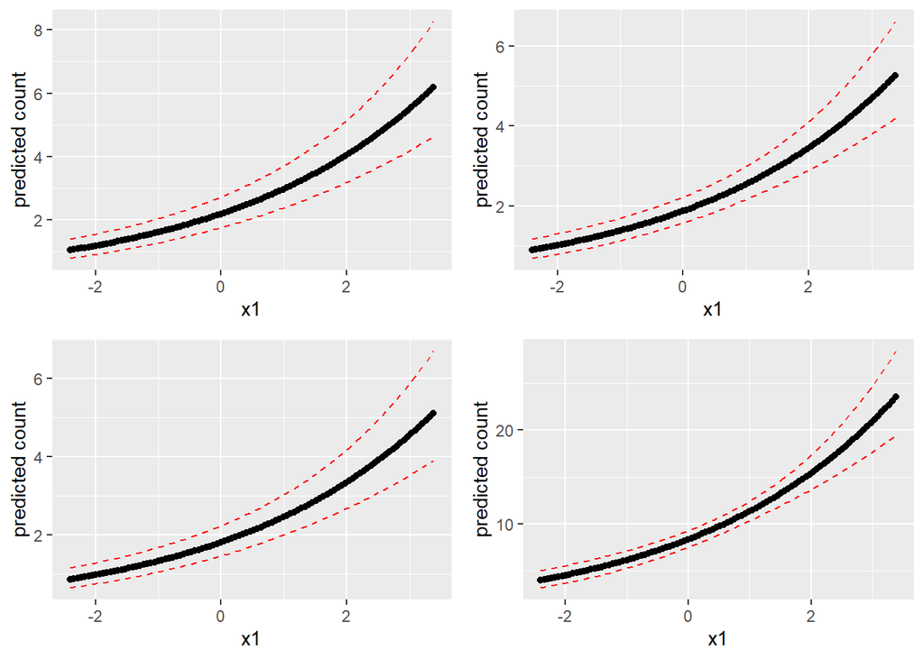

```r
newdata <- data.frame(rep = rep(0.005, 100),
                     x1 = seq(min(site_covs$x1), max(site_covs$x1), length.out = 100) ,
                     x2 = factor(c('a'),
                                 levels = c('a', 'b','c','d'))
)

prda <- predict(object = fit, newdata = newdata,

               type = 'state')


par(mfrow=c(2,2))

rep = seq(min(-2.4), max(3.38), length.out = 100)
p <- ggplot(prda, aes(rep, Predicted)) +
  geom_point() +
  xlab('x1') +# for the x axis label
  ylab('predicted count')

# 3. Add prediction intervals
a <- p + geom_line(aes(y = lower), color = "red", linetype = "dashed")+
  geom_line(aes(y = upper), color = "red", linetype = "dashed")

###############b
newdata <- data.frame(rep = rep(0.005, 100),
                      x1 = seq(min(site_covs$x1), max(site_covs$x1), length.out = 100) ,
                      x2 = factor(c('b'),
                                  levels = c('a', 'b','c','d'))
)

prdb <- predict(object = fit, newdata = newdata,

                type = 'state')



rep = seq(min(-2.4), max(3.38), length.out = 100)
p <- ggplot(prdb, aes(rep, Predicted)) +
  geom_point() +
  xlab('x1') +# for the x axis label
  ylab('predicted count')

# 3. Add prediction intervals
b <- p + geom_line(aes(y = lower), color = "red", linetype = "dashed")+
  geom_line(aes(y = upper), color = "red", linetype = "dashed")
######################## c
newdata <- data.frame(rep = rep(0.005, 100),
                      x1 = seq(min(site_covs$x1), max(site_covs$x1), length.out = 100) ,
                      x2 = factor(c('c'),
                                  levels = c('a', 'b','c','d'))
)

prdc <- predict(object = fit, newdata = newdata,

                type = 'state')



rep = seq(min(-2.4), max(3.38), length.out = 100)
p <- ggplot(prdc, aes(rep, Predicted)) +
  geom_point() +
  xlab('x1') +# for the x axis label
  ylab('predicted count')

# 3. Add prediction intervals
c <- p + geom_line(aes(y = lower), color = "red", linetype = "dashed")+
  geom_line(aes(y = upper), color = "red", linetype = "dashed")
######################## d
newdata <- data.frame(rep = rep(0.005, 100),
                      x1 = seq(min(site_covs$x1), max(site_covs$x1), length.out = 100) ,
                      x2 = factor(c('d'),
                                  levels = c('a', 'b','c','d'))
)

prdd <- predict(object = fit, newdata = newdata,

                type = 'state')


rep = seq(min(-2.4), max(3.38), length.out = 100)

p <- ggplot(prdd, aes(rep, Predicted)) +
  geom_point() +
  xlab('x1') +# for the x axis label
  ylab('predicted count')

# 3. Add prediction intervals
d <- p + geom_line(aes(y = lower), color = "red", linetype = "dashed")+
  geom_line(aes(y = upper), color = "red", linetype = "dashed")


grid.arrange(a, b,c,d, nrow = 2)
```

```r
apply(X = det_covs$rep, MARGIN = 2, FUN = max, na.rm = TRUE) # determing max number of people observed
```

```
##       j1       j2       j3
## 3.147686 3.375721 2.389230
```

```r
apply(X = det_covs$rep, MARGIN = 2, FUN = mean, na.rm = TRUE) # determing max number of people observed
```

```
##           j1           j2           j3
##  0.044105743 -0.005091672  0.021373387
```

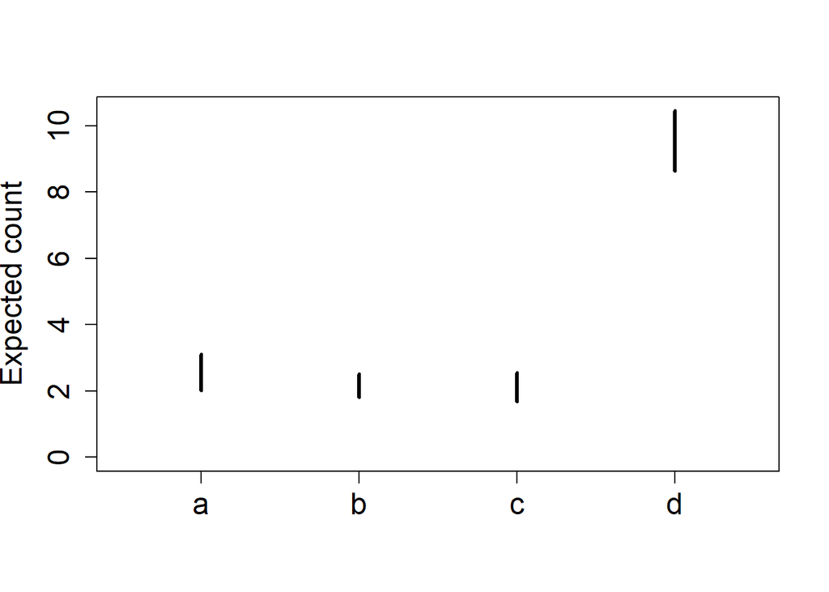

```r
newdat <- data.frame(rep = seq(min(-0.005), max(3.38), length.out = 100),
                     x1 = mean(site_covs$x1),
                     x2 = factor(c('a', 'b','c','d'),
                                 levels = c('a', 'b','c','d'))
)

prd <- predict(object = fit, newdata = newdat,

               type = 'state')

#prd

library(ggplot2)

rep = seq(min(-0.005), max(3.38), length.out = 100)

plot(x = c(0, 0), y = prd[1, c('lower', 'upper')],
     ylim = c(0, prd[4, 'upper']),
      type = 'l', xlim = c(-0.5, 3.5), xaxt = "n",
     xlab = '', ylab = 'Expected count',
     cex.axis = 1.5, cex.lab = 1.5, lwd = 3)
lines(x = c(1, 1), y = prd[2, c('lower', 'upper')], lwd = 3)
lines(x = c(2, 2), y = prd[3, c('lower', 'upper')], lwd = 3)
lines(x = c(3, 3), y = prd[4, c('lower', 'upper')], lwd = 3)
#points(x = c(0, 1,2,3), y = prd[, 'Predicted'], pch = 16,cex = 3)
axis(side = 1, at = c(0, 1,2,3),
     labels = c('a', 'b','c','d'),
     cex.axis = 1.5)
```

#5. Use contrasts to compare expected abundance between all pairwise #levels of variable x2. Obtain p-values #associated with each contrast and tell me whether you reject or fail to reject each null hypothesis tested.

```r
x <- matrix(
  c(0, 0, 1, -1, 0,
    0, 0, 1, 0, -1,
    0, 0, 0, 1, -1),
  nrow = 3, byrow = T
)
x
```

```
##      [,1] [,2] [,3] [,4] [,5]
## [1,]    0    0    1   -1    0
## [2,]    0    0    1    0   -1
## [3,]    0    0    0    1   -1
```

```r
lin_com <- linearComb(obj = fit, coefficients = x,

                      type = 'state')

lin_com
```

```
## Linear combination(s) of Abundance estimate(s)
##
##   Estimate     SE (Intercept) x1 x2b x2c x2d
## 1   0.0285 0.1332           0  0   1  -1   0
## 2  -1.4958 0.0935           0  0   1   0  -1
## 3  -1.5243 0.1140           0  0   0   1  -1
```

```r
# wald test
w <- coef(lin_com) / SE(lin_com)
w
```

```
## [1]   0.2140043 -15.9929898 -13.3713082
```

```r
#Calculating p-values
2 * pnorm(-1 * abs(w))
```

```
## [1] 8.305437e-01 1.430000e-57 8.896230e-41
```